# Risk Factor Analysis

## Outcome Variable

**Outcome Variable:** haz

## Predictor Variables

**Intervention Variable:** hhwealth_quart

**Adjustment Set:**

- arm
- sex
- W_mage
- meducyrs
- feducyrs
- W_gagebrth
- W_birthwt
- W_birthlen
- W_nchldlt5
- W_parity
- delta_W_mage
- delta_meducyrs
- delta_feducyrs
- delta_W_gagebrth
- delta_W_birthwt
- delta_W_birthlen
- delta_W_nchldlt5
- delta_W_parity

## Stratifying Variables

The analysis was stratified on these variable(s):

- agecat

## Data Summary

| agecat | hhwealth_quart | n_cell | n | outcome_variable |
| --- | --- | --- | --- | --- |
| Birth | Wealth Q4 | 7673 | 31607 | haz |
| Birth | Wealth Q1 | 7929 | 31607 | haz |
| Birth | Wealth Q2 | 7742 | 31607 | haz |
| Birth | Wealth Q3 | 8263 | 31607 | haz |
| 6 months | Wealth Q4 | 8928 | 31942 | haz |
| 6 months | Wealth Q1 | 7309 | 31942 | haz |
| 6 months | Wealth Q2 | 7380 | 31942 | haz |
| 6 months | Wealth Q3 | 8325 | 31942 | haz |
| 24 months | Wealth Q4 | 5713 | 20929 | haz |
| 24 months | Wealth Q1 | 4776 | 20929 | haz |
| 24 months | Wealth Q2 | 4960 | 20929 | haz |
| 24 months | Wealth Q3 | 5480 | 20929 | haz |

The following strata were considered:

- agecat: 24 months
- agecat: 6 months
- agecat: Birth

## Methods Detail

We’re interested in the causal parameters $E[Y_a]$ for all values of $a \in \mathcal{A}$. These parameters represent the mean outcome if, possibly contrary to fact, we intervened to set all units to have $A=a$. Under the randomization and positivity assumptions, these are identified by the statistical parameters $\psi_a=E_W[E_{Y|A,W}(Y|A=a,W)]$. In addition, we’re interested in the mean of $Y$, $E[Y]$ under no intervention (the observed mean). We will estimate these parameters by using SuperLearner to fit the relevant likelihood factors – $E_{Y|A,W}(Y|A=a,W)$ and $p(A=a|W)$, and then updating our likelihood fit using a joint TMLE.

For unadjusted analyses ($W=\{\}$), initial likelihoods were estimated using Lrnr_glm to estimate the simple $E(Y|A)$ and Lrnr_mean to estimate $p(A)$. For adjusted analyses, a small library containing Lrnr_glmnet, Lrnr_xgboost, and Lrnr_mean was used.

Having estimated these parameters, we will then use the delta method to estimate relative risks and attributable risks relative to a prespecified baseline level of $A$.

# Results Detail

## Results Plots

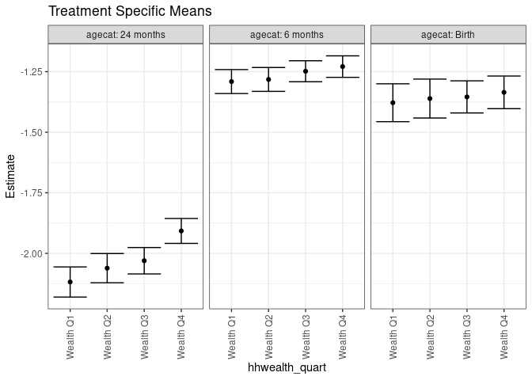

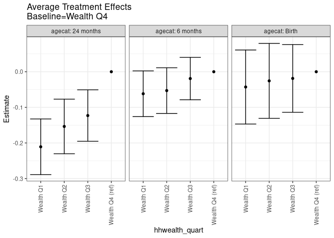

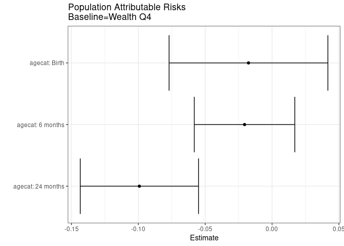

## Results Table

### Parameter: TSM

| agecat | intervention_level | baseline_level | estimate | ci_lower | ci_upper |
| --- | --- | --- | --- | --- | --- |
| Birth | Wealth Q4 | NA | -1.335356 | -1.402735 | -1.267977 |
| Birth | Wealth Q1 | NA | -1.378248 | -1.456522 | -1.299973 |
| Birth | Wealth Q2 | NA | -1.361008 | -1.441314 | -1.280702 |
| Birth | Wealth Q3 | NA | -1.354134 | -1.420416 | -1.287852 |
| 6 months | Wealth Q4 | NA | -1.229083 | -1.273486 | -1.184680 |
| 6 months | Wealth Q1 | NA | -1.290873 | -1.340334 | -1.241411 |
| 6 months | Wealth Q2 | NA | -1.282041 | -1.331284 | -1.232798 |
| 6 months | Wealth Q3 | NA | -1.248256 | -1.291614 | -1.204898 |
| 24 months | Wealth Q4 | NA | -1.907466 | -1.958954 | -1.855977 |
| 24 months | Wealth Q1 | NA | -2.118196 | -2.180430 | -2.055963 |
| 24 months | Wealth Q2 | NA | -2.061095 | -2.121413 | -2.000777 |
| 24 months | Wealth Q3 | NA | -2.030475 | -2.084986 | -1.975965 |

### Parameter: E(Y)

| agecat | intervention_level | baseline_level | estimate | ci_lower | ci_upper |
| --- | --- | --- | --- | --- | --- |
| Birth | NA | NA | -1.352985 | -1.382952 | -1.323019 |
| 6 months | NA | NA | -1.249666 | -1.273778 | -1.225554 |
| 24 months | NA | NA | -2.006679 | -2.035833 | -1.977524 |

### Parameter: ATE

| agecat | intervention_level | baseline_level | estimate | ci_lower | ci_upper |
| --- | --- | --- | --- | --- | --- |
| Birth | Wealth Q4 | Wealth Q4 | 0.0000000 | 0.0000000 | 0.0000000 |
| Birth | Wealth Q1 | Wealth Q4 | -0.0428914 | -0.1468350 | 0.0610522 |
| Birth | Wealth Q2 | Wealth Q4 | -0.0256519 | -0.1308115 | 0.0795077 |
| Birth | Wealth Q3 | Wealth Q4 | -0.0187778 | -0.1139031 | 0.0763474 |
| 6 months | Wealth Q4 | Wealth Q4 | 0.0000000 | 0.0000000 | 0.0000000 |
| 6 months | Wealth Q1 | Wealth Q4 | -0.0617895 | -0.1259198 | 0.0023407 |
| 6 months | Wealth Q2 | Wealth Q4 | -0.0529579 | -0.1170898 | 0.0111741 |
| 6 months | Wealth Q3 | Wealth Q4 | -0.0191729 | -0.0787789 | 0.0404331 |
| 24 months | Wealth Q4 | Wealth Q4 | 0.0000000 | 0.0000000 | 0.0000000 |
| 24 months | Wealth Q1 | Wealth Q4 | -0.2107307 | -0.2889089 | -0.1325526 |
| 24 months | Wealth Q2 | Wealth Q4 | -0.1536290 | -0.2302750 | -0.0769830 |
| 24 months | Wealth Q3 | Wealth Q4 | -0.1230096 | -0.1952213 | -0.0507980 |

### Parameter: PAR

| agecat | intervention_level | baseline_level | estimate | ci_lower | ci_upper |
| --- | --- | --- | --- | --- | --- |
| Birth | Wealth Q4 | NA | -0.0176293 | -0.0769883 | 0.0417297 |
| 6 months | Wealth Q4 | NA | -0.0205830 | -0.0581559 | 0.0169898 |
| 24 months | Wealth Q4 | NA | -0.0992129 | -0.1434323 | -0.0549936 |